# Weight Lifting Prediction Model

Soo Ingrisone 08/10/20

## Overview

One thing that people regularly do is quantify how much of a particular activity they do, but they rarely quantify how well they do it. The data is collected from accelerometers on the belt, forearm, arm, and dumbell of 6 participants. The goal of this project is to predict the manner in which they did the exercise.The report describes how the model is built, how cross validation is used, expected out of sample error, and why the choices are made. Finally, the suggested prediction model is used to predict 20 different test cases.

## Data Processing

Load the neceaary library

```r
library(caret)
library(rattle)
```

First, the data is imported from the websites.

```r
url_train <- "https://d396qusza40orc.cloudfront.net/predmachlearn/pml-training.csv"
url_test <- "https://d396qusza40orc.cloudfront.net/predmachlearn/pml-testing.csv"
download.file(url_train, destfile = "pml-training.csv")
download.file(url_test, destfile = "pml-testing.csv")
training<-read.csv('pml-training.csv', sep=',', header=TRUE)
testing<-read.csv('pml-testing.csv', sep=',', header=TRUE)
dim(training); dim(testing)
```

```
## [1] 19622   160
```

```
## [1]  20 160
```

The choice of specific predictors is based on removing variables containing many NAs. In addition, columns that are not associated with exercise are deleted, i.e., “X”, “user_name”, “raw_timestamp_part_1”, “raw_timestamp_part_2”, “cvtd_timestamp”, “new_window”, “num_window”. They are the first seven columns in the data. The same rule is applied to testing data.

```r
training <- training[, colSums(is.na(training)) == 0]
training <- training[, -(1:7)]
testing <- testing[, colSums(is.na(testing)) == 0]
testing <- testing[, -(1:7)]
```

The training data is split into train and validation sets with 60/40 ratio. In order to be reproducible, the seed is set to 123.

```r
set.seed(123)
inTrain = createDataPartition(training$classe, p = .6, list=FALSE)
train_set = training[ inTrain,]
validation_set = training[-inTrain,]
dim(train_set); dim(validation_set)
```

```
## [1] 11776    86
```

```
## [1] 7846   86
```

The features are selected further by removing near zero variance predictors, with the nearZeroVar function.

```r
nzv <- nearZeroVar(train_set)
train_set <- train_set[, -nzv]
validation_set  <- validation_set[, -nzv]
dim(train_set); dim(validation_set)
```

```
## [1] 11776    53
```

```
## [1] 7846   53
```

## Model Selection

### 1. Linear Discriminant Analysis

```r
fit_lda <- train(classe~., method="lda", data = train_set, trControl = trainControl(method="cv"), number=5, repeats=1)
pred_lda <- predict(fit_lda, validation_set)
confusionMatrix(pred_lda, as.factor(validation_set$classe))
```

```
## Confusion Matrix and Statistics
##
##           Reference
## Prediction    A    B    C    D    E
##          A 1784  245  139   79   59
##          B   54  970  146   51  246
##          C  192  184  862  173  141
##          D  193   53  188  919  128
##          E    9   66   33   64  868
##
## Overall Statistics
##
##                Accuracy : 0.6886
##                  95% CI : (0.6783, 0.6989)
##     No Information Rate : 0.2845
##     P-Value [Acc > NIR] : < 2.2e-16
##
##                   Kappa : 0.6061
##
##  Mcnemar's Test P-Value : < 2.2e-16
##
## Statistics by Class:
##
##                      Class: A Class: B Class: C Class: D Class: E
## Sensitivity            0.7993   0.6390   0.6301   0.7146   0.6019
## Specificity            0.9070   0.9215   0.8935   0.9143   0.9731
## Pos Pred Value         0.7736   0.6612   0.5554   0.6205   0.8346
## Neg Pred Value         0.9191   0.9141   0.9196   0.9423   0.9157
## Prevalence             0.2845   0.1935   0.1744   0.1639   0.1838
## Detection Rate         0.2274   0.1236   0.1099   0.1171   0.1106
## Detection Prevalence   0.2939   0.1870   0.1978   0.1888   0.1326
## Balanced Accuracy      0.8532   0.7802   0.7618   0.8145   0.7875
```

### 2. Recursive Partitioning And Regression Trees model

```r
fit_rpart <-  train(classe~., method="rpart", data = train_set, trControl=trainControl(method="cv", number=3, allowParallel=T))
pred_rpart <- predict(fit_rpart, validation_set)
confusionMatrix(pred_rpart, as.factor(validation_set$classe))
```

```
## Confusion Matrix and Statistics
##
##           Reference
## Prediction    A    B    C    D    E
##          A 2024  652  615  590  190
##          B   37  518   43  207  213
##          C  168  348  710  489  364
##          D    0    0    0    0    0
##          E    3    0    0    0  675
##
## Overall Statistics
##
##                Accuracy : 0.5005
##                  95% CI : (0.4894, 0.5116)
##     No Information Rate : 0.2845
##     P-Value [Acc > NIR] : < 2.2e-16
##
##                   Kappa : 0.3473
##
##  Mcnemar's Test P-Value : NA
##
## Statistics by Class:
##
##                      Class: A Class: B Class: C Class: D Class: E
## Sensitivity            0.9068  0.34124  0.51901   0.0000  0.46810
## Specificity            0.6354  0.92099  0.78867   1.0000  0.99953
## Pos Pred Value         0.4972  0.50884  0.34151      NaN  0.99558
## Neg Pred Value         0.9449  0.85354  0.88590   0.8361  0.89300
## Prevalence             0.2845  0.19347  0.17436   0.1639  0.18379
## Detection Rate         0.2580  0.06602  0.09049   0.0000  0.08603
## Detection Prevalence   0.5189  0.12975  0.26498   0.0000  0.08641
## Balanced Accuracy      0.7711  0.63111  0.65384   0.5000  0.73382
```

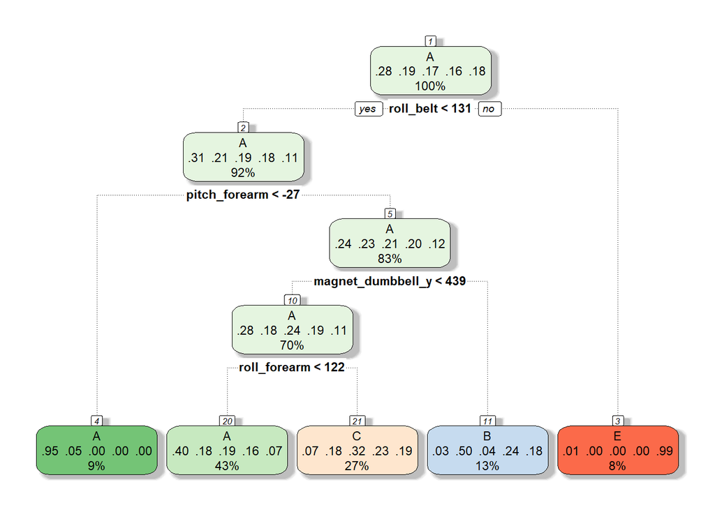

```r
fancyRpartPlot(fit_rpart$finalModel, sub="")
```

Basd on 3-fold cross validation method, the overall accuracy of the model classification is 0.5005.

### 3. Gradient Boost Model

```r
fit_gbm <-  train(classe~., method="gbm", data = train_set, verbose=FALSE, trControl=trainControl(method="cv", number=2, allowParallel=T))
pred_gbm <- predict(fit_gbm, validation_set)
confusionMatrix(pred_gbm, as.factor(validation_set$classe))
```

```
## Confusion Matrix and Statistics
##
##           Reference
## Prediction    A    B    C    D    E
##          A 2189   48    0    3    4
##          B   28 1430   51    7   20
##          C    7   39 1298   39   12
##          D    3    1   17 1220   10
##          E    5    0    2   17 1396
##
## Overall Statistics
##
##                Accuracy : 0.9601
##                  95% CI : (0.9555, 0.9643)
##     No Information Rate : 0.2845
##     P-Value [Acc > NIR] : < 2.2e-16
##
##                   Kappa : 0.9495
##
##  Mcnemar's Test P-Value : 1.988e-08
##
## Statistics by Class:
##
##                      Class: A Class: B Class: C Class: D Class: E
## Sensitivity            0.9807   0.9420   0.9488   0.9487   0.9681
## Specificity            0.9902   0.9832   0.9850   0.9953   0.9963
## Pos Pred Value         0.9755   0.9310   0.9305   0.9752   0.9831
## Neg Pred Value         0.9923   0.9861   0.9891   0.9900   0.9928
## Prevalence             0.2845   0.1935   0.1744   0.1639   0.1838
## Detection Rate         0.2790   0.1823   0.1654   0.1555   0.1779
## Detection Prevalence   0.2860   0.1958   0.1778   0.1594   0.1810
## Balanced Accuracy      0.9855   0.9626   0.9669   0.9720   0.9822
```

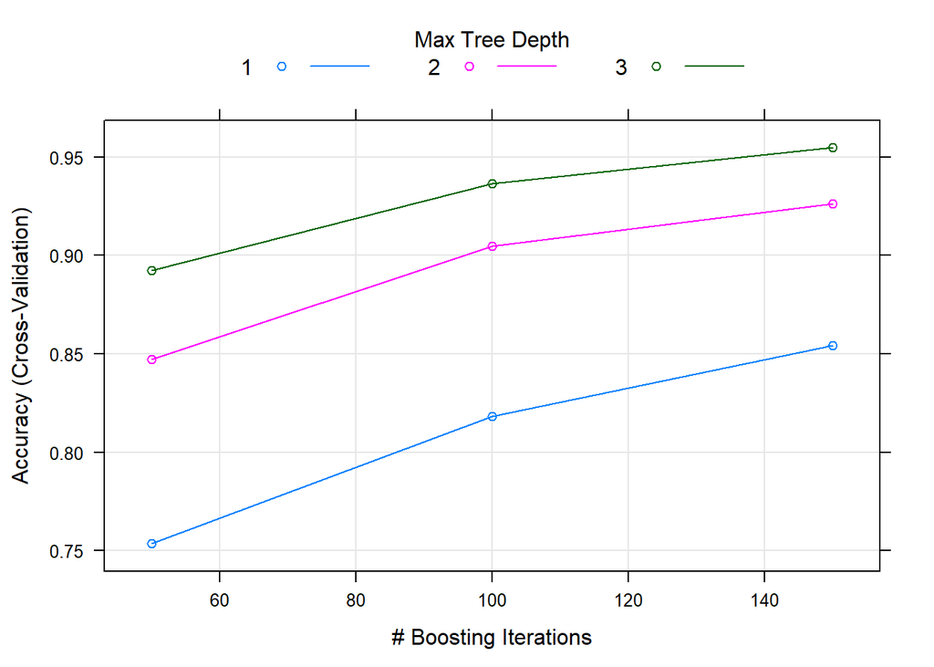

```r
plot(fit_gbm)
```

The 2-fold cross validation method is used to fit the model. The overall accuracy of the model classification is 0.9601. The best tuning parameters was 150 trees, with depth 3, shrinkage = 0.1 and number of min observations in node = 10.

### 4. Random Forest model

```r
fit_rf <-  train(classe~., method="rf", data = train_set, trControl=trainControl(method="cv", number=2, allowParallel=T))
pred_rf <- predict(fit_rf, validation_set)
confusionMatrix(pred_rf, as.factor(validation_set$classe))
```

```
## Confusion Matrix and Statistics
##
##           Reference
## Prediction    A    B    C    D    E
##          A 2225    7    0    0    0
##          B    5 1509   15    0    0
##          C    0    2 1344   12    2
##          D    0    0    9 1273    2
##          E    2    0    0    1 1438
##
## Overall Statistics
##
##                Accuracy : 0.9927
##                  95% CI : (0.9906, 0.9945)
##     No Information Rate : 0.2845
##     P-Value [Acc > NIR] : < 2.2e-16
##
##                   Kappa : 0.9908
##
##  Mcnemar's Test P-Value : NA
##
## Statistics by Class:
##
##                      Class: A Class: B Class: C Class: D Class: E
## Sensitivity            0.9969   0.9941   0.9825   0.9899   0.9972
## Specificity            0.9988   0.9968   0.9975   0.9983   0.9995
## Pos Pred Value         0.9969   0.9869   0.9882   0.9914   0.9979
## Neg Pred Value         0.9988   0.9986   0.9963   0.9980   0.9994
## Prevalence             0.2845   0.1935   0.1744   0.1639   0.1838
## Detection Rate         0.2836   0.1923   0.1713   0.1622   0.1833
## Detection Prevalence   0.2845   0.1949   0.1733   0.1637   0.1837
## Balanced Accuracy      0.9978   0.9955   0.9900   0.9941   0.9984
```

The overall accuracy of the model classification is 0.9927 using 2-fold cross validation method.

### Final Model

The accuracy of the random forest model is, as expected, much higher than other models, over 0.99. Random Forest model performed better and constitutes the model of choice for predicting the 20 observations of the original pml-testing.csv dataset.

```r
prediction <- predict(fit_rf, testing)
prediction
```

```
##  [1] B A B A A E D B A A B C B A E E A B B B
## Levels: A B C D E
```